# 2.2 Assessment: Continuous Probability

Assessment due May 20, 2021 05:01 +03 In this 3-part question, you will convert raw ACT scores to Z-scores and answer some questions about them.

Convert act_scores to Z-scores. Recall from Data Visualization (the second course in this series) that to standardize values (convert values into Z-scores, that is, values distributed with a mean of 0 and standard deviation of 1), you must subtract the mean and then divide by the standard deviation. Use the mean and standard deviation of act_scores, not the original values used to generate random test scores.

Question 3a 0.0/1.0 point (graded) What is the probability of a Z-score greater than 2 (2 standard deviations above the mean)?

```r
z_scores <- (act_scores - mean(act_scores))/sd(act_scores)
mean(z_scores > 2)
```

```
[1] 0.0233
```

Question 3b 0.0/1.0 point (graded) What ACT score value corresponds to 2 standard deviations above the mean (Z = 2)?

```r
          2*sd(act_scores) + mean(act_scores)
```

```
[1] 32.1906
```

Question 3c 0.0/1.0 point (graded) A Z-score of 2 corresponds roughly to the 97.5th percentile.

Use qnorm() to determine the 97.5th percentile of normally distributed data with the mean and standard deviation observed in act_scores.

What is the 97.5th percentile of act_scores?

```r
          qnorm(.975, mean(act_scores), sd(act_scores))
```

```
[1] 31.96338
```

In this 4-part question, you will write a function to create a CDF for ACT scores.

Write a function that takes a value and produces the probability of an ACT score less than or equal to that value (the CDF). Apply this function to the range 1 to 36.

Question 4a 0.0/1.0 point (graded) What is the minimum integer score such that the probability of that score or lower is at least .95? Your answer should be an integer 1-36.

```r
cdf <- sapply(1:36, function (x){
  mean(act_scores <= x)
})
min(which(cdf >= .95))
```

```
[1] 31
```

Question 4b 1/1 point (graded) Use qnorm() to determine the expected 95th percentile, the value for which the probability of receiving that score or lower is 0.95, given a mean score of 20.9 and standard deviation of 5.7.

What is the expected 95th percentile of ACT scores?

```r
          qnorm(.95, 20.9, 5.7)
```

```
[1] 30.27567
```

Question 4c 0.0/1.0 point (graded) As discussed in the Data Visualization course, we can use quantile() to determine sample quantiles from the data.

Make a vector containing the quantiles for p <- seq(0.01, 0.99, 0.01), the 1st through 99th percentiles of the act_scores data. Save these as sample_quantiles.

In what percentile is a score of 26? Your answer should be an integer (i.e. 60), not a percent or fraction. Note that a score between the 98th and 99th percentile should be considered the 98th percentile, for example, and that quantile numbers are used as names for the vector sample_quantiles.

```r
p <- seq(0.01, 0.99, 0.01)
sample_quantiles <- quantile(act_scores, p)
names(sample_quantiles[max(which(sample_quantiles < 26))])
```

```
[1] "82%"
```

Question 4d 0.0/1.0 point (graded) Make a corresponding set of theoretical quantiles using qnorm() over the interval p <- seq(0.01, 0.99, 0.01) with mean 20.9 and standard deviation 5.7. Save these as theoretical_quantiles. Make a QQ-plot graphing sample_quantiles on the y-axis versus theoretical_quantiles on the x-axis.

Which of the following graphs is correct?

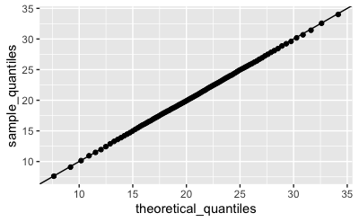

```r
p <- seq(0.01, 0.99, 0.01)
sample_quantiles <- quantile(act_scores, p)
theoretical_quantiles <- qnorm(p, 20.9, 5.7)
qplot(theoretical_quantiles, sample_quantiles) + geom_abline()
```